# HW2

Tayler Sindhu

Fall 2019

# Regression

1. Split data into training and test set (75% in train set, 25% in test set)

```r
# Set seed so random sampling is reproducible
set.seed(486)

# take a random sample of 75% of rows idices
train <- sort(sample(nrow(airquality), nrow(airquality)*.75))
# subsets the dataframe by the rows selected in the sample function
train_regression <- airquality[train,]
test_regression = airquality[-train,]
```

### Linear Regression

- Assumes a linear relationship.
- Independent variables should not be correlated (no mulitcollinearity)
- The number of observations should be greater than the number of independent variables.

$$RSS=\sum(y_i - \hat{y_i})^2$$
We will predict the response of the Temperature based on Wind.

This is the data we will fit a linear model to.

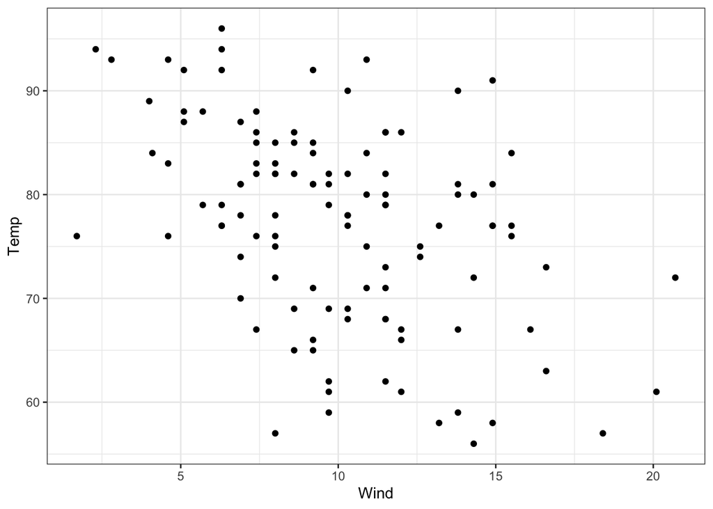

```r
 ggplot(data = train_regression) +
   geom_point(aes(x=Wind, y=Temp)) +
   theme_bw()
```

2. Create and fit a linear model to predict Temperature from Wind using the training set

```r
#help(train)
set.seed(40)
linear_regression <- train(Temp ~ Wind, data= train_regression, method = "lm", na.action = na.omit)
```

3. Vizualize how your model performed on the train data by plotting the regression line on top of the train data points.

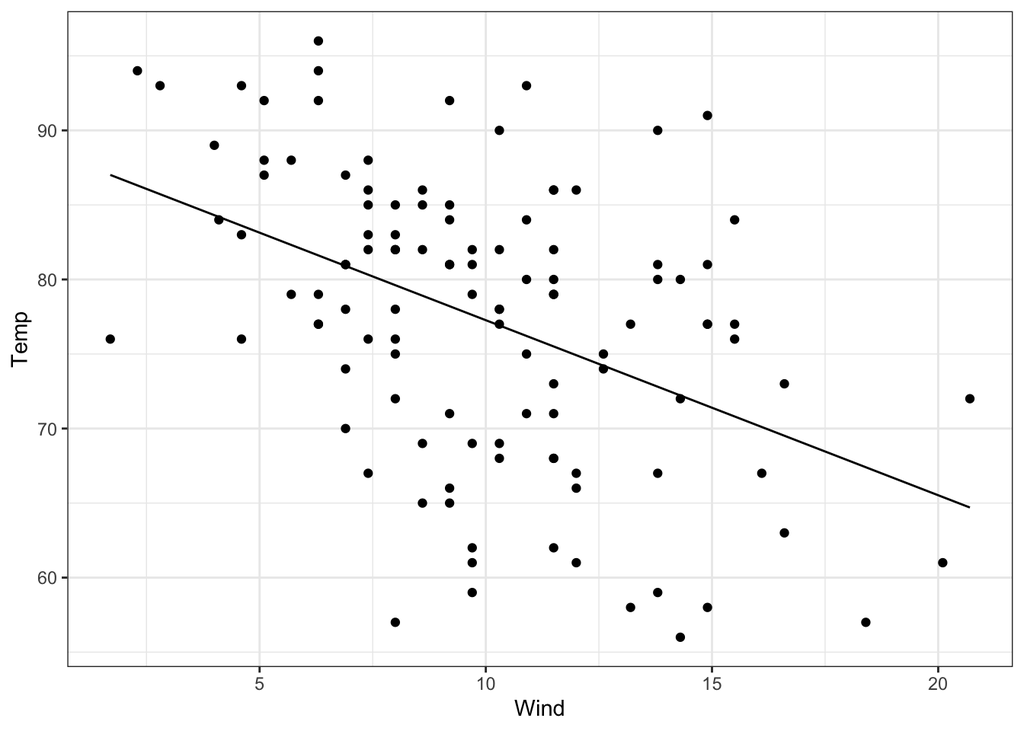

```r
# plotted predicted values of train data

predicted_values_train = predict(linear_regression, train_regression)

 ggplot() +
   geom_point(data = train_regression, aes(x=Wind, y=Temp)) +
   geom_line(data = train_regression, aes(x=Wind, y=predicted_values_train))+
   theme_bw()
```

4. Explore how the model performs on the test data. For Linear Regression:
- The residuals should be close to zero.
- There should be equal variance around the regression line (homoscedasticity).
- Residuals should be normally distributed.
- Independent variables and residuals should not be correlated.

4 a) See how the model performs on the test data

```r
#help(predict)
linear_predict <- predict(linear_regression, newdata=test_regression)
linear_predict
```

```
##        6       11       14       16       25       32       33       37
## 71.51358 80.90748 76.21053 75.50599 69.51738 78.91128 77.61962 72.21813
##       41       51       55       58       67       70       71       73
## 75.50599 76.91507 81.61202 76.91507 76.21053 82.31656 80.32036 72.21813
##       74       79       81       87       96       98      101      102
## 71.51358 81.61202 75.50599 78.91128 80.90748 83.60822 79.61582 78.91128
##      105      106      110      111      117      118      120      124
## 75.50599 77.61962 80.32036 76.21053 85.01731 79.61582 77.61962 80.90748
##      128      133      134      141      144      146      151
## 80.32036 77.61962 71.51358 76.91507 74.21433 76.91507 72.21813
```

4 b) Look at the residuals. Are they close to zero?

```r
#look at the median residual value. Close to zero is best
#help(summary)
summary(linear_regression)
```

```
##
## Call:
## lm(formula = .outcome ~ ., data = dat)
##
## Residuals:
##     Min      1Q  Median      3Q     Max
## -22.616  -6.810   1.530   6.015  19.486
##
## Coefficients:
##             Estimate Std. Error t value Pr(>|t|)
## (Intercept)  89.0097     2.3800  37.399  < 2e-16 ***
## Wind         -1.1742     0.2241  -5.239 7.65e-07 ***
## ---
## Signif. codes:  0 '***' 0.001 '**' 0.01 '*' 0.05 '.' 0.1 ' ' 1
##
## Residual standard error: 8.724 on 112 degrees of freedom
## Multiple R-squared:  0.1968, Adjusted R-squared:  0.1897
## F-statistic: 27.45 on 1 and 112 DF,  p-value: 7.655e-07
```

**The median residual value is 1.53, and appears relatively centered around zero.**

4 c) Plot predicted temperature vs observed temperature. A strong model should show a strong correlation

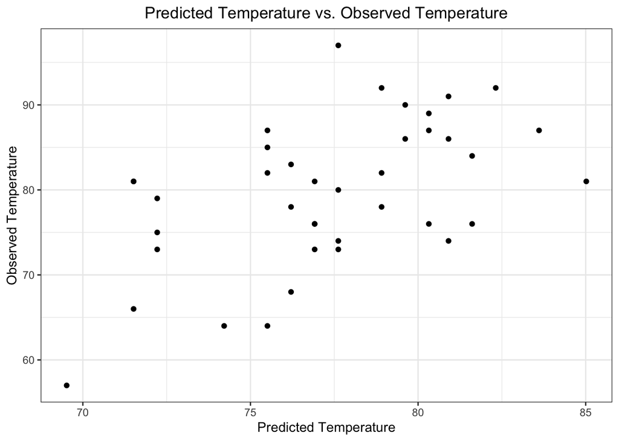

```r
# on test dataset?
 ggplot() +
   geom_point(data = test_regression, aes(x=linear_predict, y=Temp)) +
   theme_bw() +
  xlab("Predicted Temperature") +
  ylab("Observed Temperature") +
  ggtitle("Predicted Temperature vs. Observed Temperature") +
  theme(plot.title = element_text(hjust = 0.5))
```

4 d) Visualize the predicted values in relation to the real data points. Look for homoscedasticity

```r
# Extract coefficients from the model
coef(linear_regression$finalModel)
```

```
## (Intercept)        Wind
##   89.009715   -1.174237
```

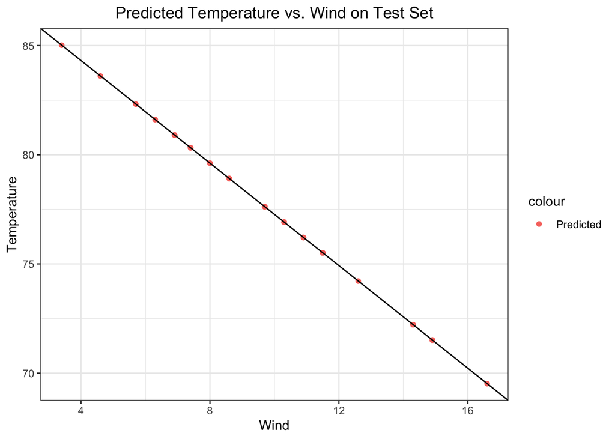

```r
# plot the regression line on the predicted values
 ggplot(data=test_regression) +
   geom_point(aes(x=Wind, y=linear_predict, col="Predicted")) +
   #geom_point(aes(x=Wind, y=Temp, color="Observed")) +
   geom_abline(intercept = 89.010, slope = -1.174) +
   #geom_segment(aes(x=Wind, y=linear_predict,yend=Temp, xend= Wind), color="black") +
   theme_bw()  +
   xlab("Wind") +
   ylab("Temperature") +
   ggtitle("Predicted Temperature vs. Wind on Test Set") +
   theme(plot.title = element_text(hjust = 0.5))
```

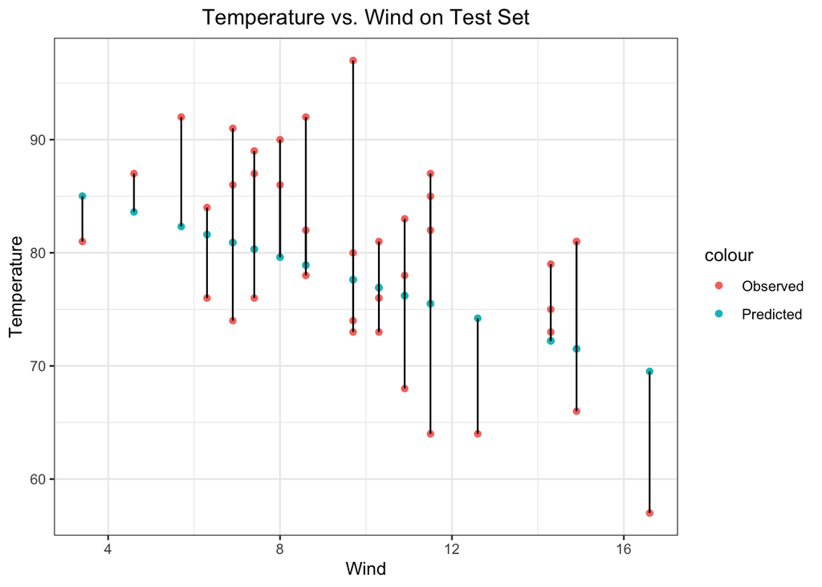

```r
# plot the original test values
# adding observed values into plot, removed regression line
 ggplot(data=test_regression) +
   geom_point(aes(x=Wind, y=linear_predict, col="Predicted")) +
   geom_point(aes(x=Wind, y=Temp, color="Observed")) +
  # geom_abline(intercept = 89.010, slope = -1.174) +
   geom_segment(aes(x=Wind, y=linear_predict,yend=Temp, xend= Wind), color="black") +
   theme_bw()  +
   xlab("Wind") +
   ylab("Temperature") +
   ggtitle("Temperature vs. Wind on Test Set") +
   theme(plot.title = element_text(hjust = 0.5))
```

4 e) Residuals should be normally distributed. Plot the density of the residuals

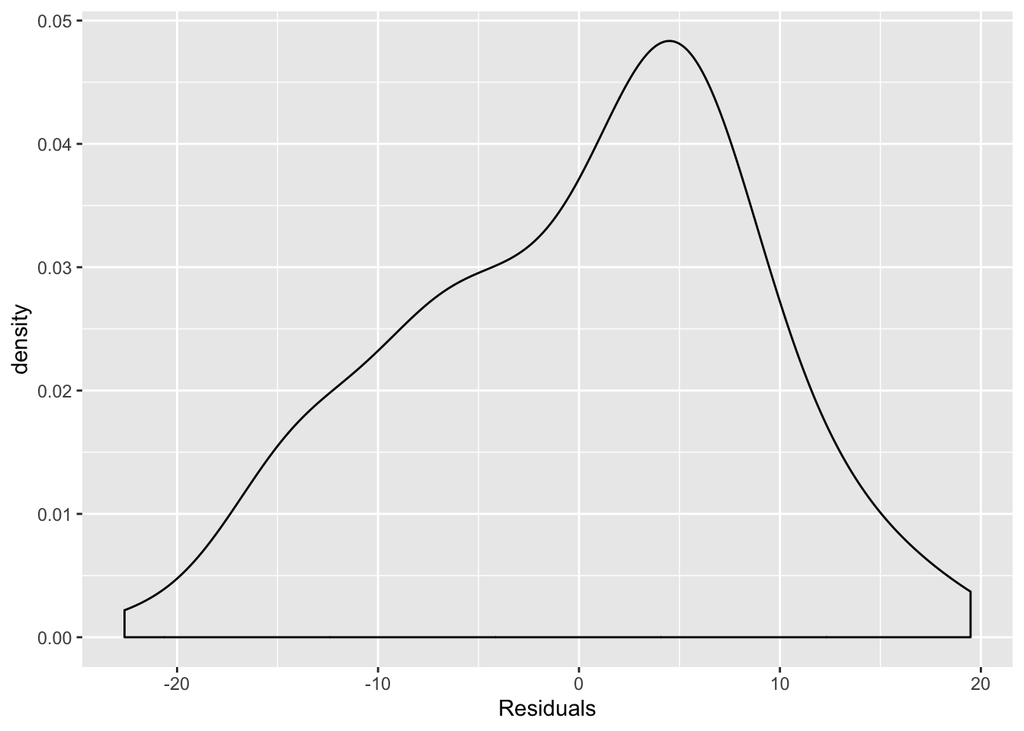

```r
#residuals_lin <- residuals(linear_regression)
#ggplot(data=residvpredict) +
#  geom_density(aes(residual))

residuals_lin <- residuals(linear_regression)

# Makes dataframe of training data and residuals of training data
residvpredict <- data.frame(predicted_values_train, residuals_lin)

ggplot(data=residvpredict) +
  geom_density(aes(x=residuals_lin)) +
  xlab("Residuals")
```

4 f) Independent variables and residuals should not be correlated

```r
cor.test(train_regression$Wind, resid(linear_regression))
```

```
##
##  Pearson's product-moment correlation
##
## data:  train_regression$Wind and resid(linear_regression)
## t = -8.9576e-16, df = 112, p-value = 1
## alternative hypothesis: true correlation is not equal to 0
## 95 percent confidence interval:
##  -0.1839148  0.1839148
## sample estimates:
##           cor
## -8.464107e-17
```

### Linear Regression with Regularization

5. Create a linear model using L1 or L2 regularization to predict Temperature from Wind and Month variables. Plot your predicted values and the real Y values on the same plot.

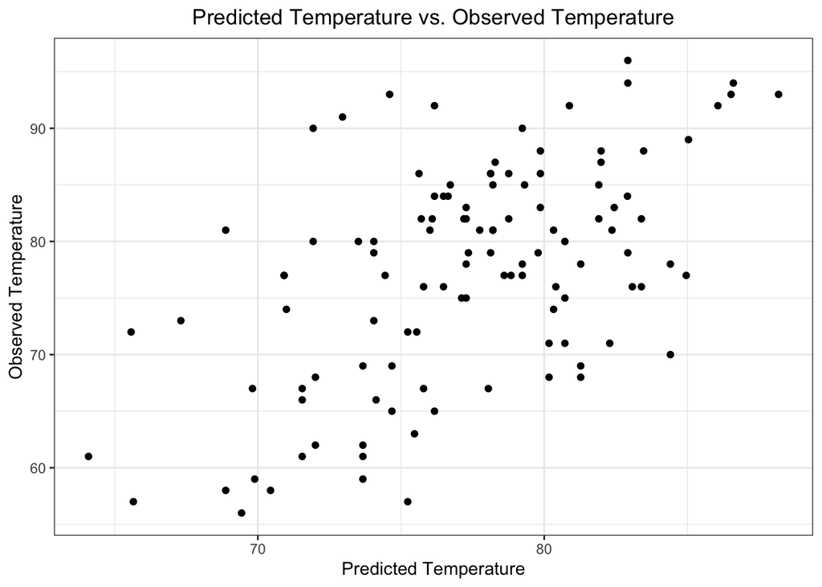

```r
# Create model
set.seed(40)
lasso_mod <- train(Temp ~ Wind + Month, data= train_regression, method = "lasso")

pred_mod_train = predict(lasso_mod, train_regression)

 ggplot() +
   geom_point(data = train_regression, aes(x=pred_mod_train, y=Temp)) +
   theme_bw() +
   xlab("Predicted Temperature") +
   ylab("Observed Temperature") +
   ggtitle("Predicted Temperature vs. Observed Temperature") +
   theme(plot.title = element_text(hjust = 0.5))
```